# EDA - A insatisfabilidade das reclamações do governo federal

**Equipe:**

- Davi Laerte
- Gabriel Fernandes
- José Ivan
- Lucas Vieira
- Yuri Kelvin

## Explorando os dados

Neste pequeno estudo exploratório, pretendemos analisar os dados referentes as reclamações sobre orgãos do governo federal e analisar os dados referentes a um experimento humano que avaliou o nível de insatisfação desse conjunto de reclamações, e com isso tentar achar e entender características importantes desses dados.

## Qual a média do tamanho de reclamações (caracteres) por orgão?

Primeiro vamos dar uma olhada em como se comporta o tamanho das reclamações por orgão (do governo federal) e tentar achar algum padrão.

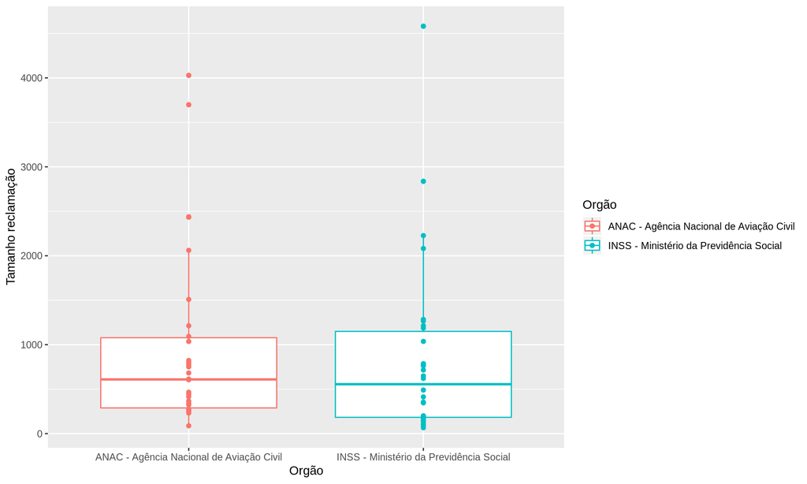

Podemos ver no gráfico acima que a mediana de tamanho da reclamação da ANAC é maior que o do INSS, apesar dos valores do INSS variarem mais, assim podemos entender que o tamanho de reclamação das duas tem distribuiçoes parecidas, apesar das medianas diferentes e do orgão INSS variar mais.

## Qual a dispersão das avaliações?

Vamos analisar agora qual a dispersão das avaliações feitas, para tanto usaremos a medida **IQR** onde quanto maior seu valor consequetemente maior a dispersão daquele dados.

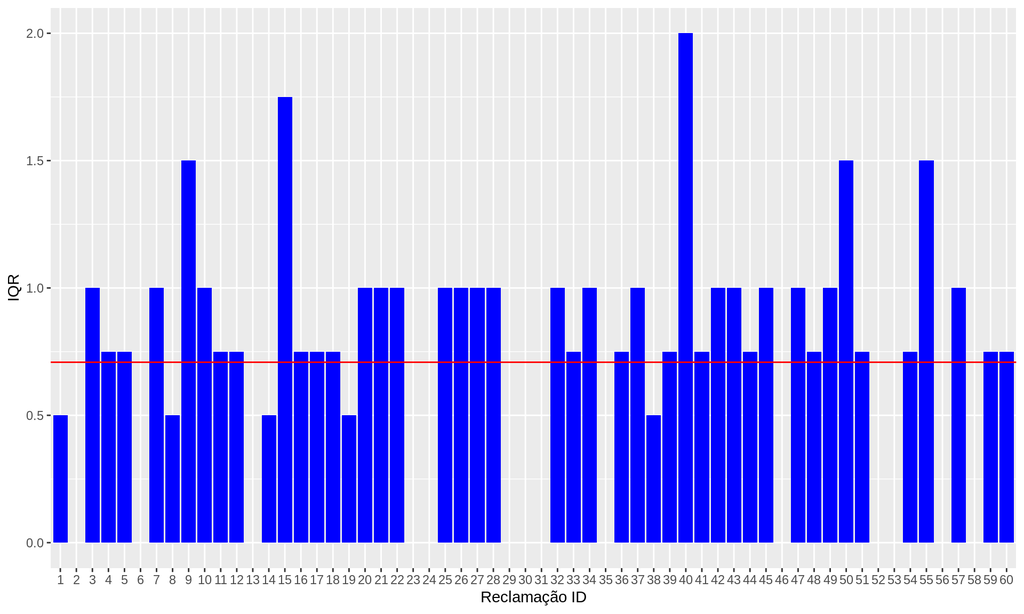

Como vemos no gráfico acima temos variação do intervalo que contém 50% dos dados (IQR) entre 0 a 2, onde a média dessas variações (linha vermelha) é de **0.708**, assim existe uma variação média de 0.708 nas notas dadas nas avaliações, onde essas notas vão de 1 a 5.

## Qual a media de insatisfabilidade por orgão?

Analisaremos agora a media de insatisfabilidade por orgão, e assim poderemos ter uma ideia de qual orgão tem mais reclamações com maior insatisfabilidade.

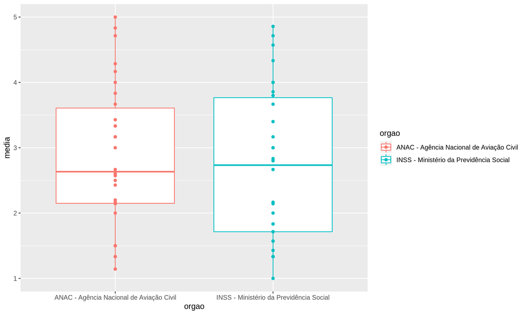

Olhando o gráfico, podemos entender que o INSS tem uma mediana maior que a ANAC, entretanto os valores estão mais distribuidos, vemos também que a ANAC possui o maior valor de insatisfabilidade.

## Número de caracteres por insatisfabilidade (Mediana)?

Veremos agora como se comporta o número de caracteres em relação aos 5 niveis de insatisfabilidade, usaremos os valores da mediana e valores da mediana que não são inteiros serão alocados nos niveis abaixo deles.

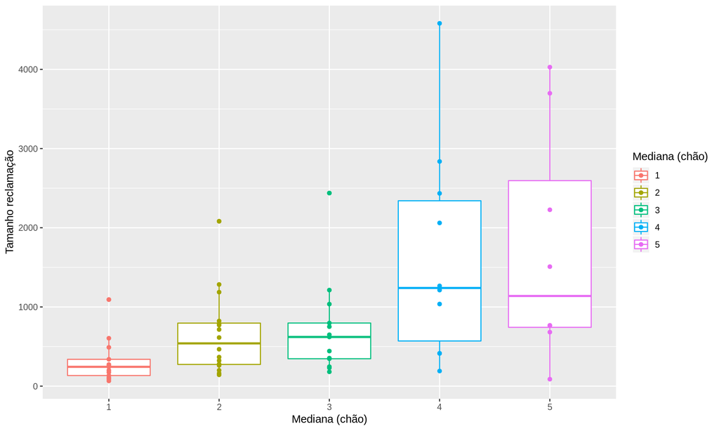

## Conclusões

Após explorar os dados, conseguimos extrair e entender muitas informações importantes como o quanto o tamanho de uma reclamação pode influenciar no nível de insatisfabilidade da reclamação e também o como se comportam os níveis de insastifabildade em relação aos orgãos do governo federal presentes nos dados, assim vimos com os dados que esses fatores são importantes e podem ser melhor analisados, pois parecem influenciar aspectos importantes das reclamações.